# Password exploration

## Data pre-process - 1

### Read password

```python
import pandas as pd
import numpy as np

np.random.seed(8)
data = pd.read_csv('../data/38650-password-sktorrent.txt', header=None)
```

### Create a table

```python
import re

data.columns = ['original']

data['original'] = data['original'].astype(str)
```

Wordsegmet Package and function for preprocessing list

```python
import wordsegment as ws

from wordsegment import load, segment

load()

def flat(l):
    for k in l:
        if not isinstance(k, (list, tuple)):
            yield k
        else:
            yield from flat(k)
```

### Splitting

```python
# split every characters
data["simplesplit"] = ""
# split special characters
data["specialcharsplit"] = ""
# split words but don't remain the captial characters
data["extrawordsplit"] = ""



for index, row in data.iterrows():
    # simple split for each row
    row['simplesplit'] = list(row['original'])
    row['specialcharsplit'] = re.findall(r'[0-9]+|[a-zA-Z]+|[^a-zA-Z0-9]+',row['original'])

    passwdstring=[]
    for i in row['specialcharsplit']:
        templist = segment(i)
        if(templist):
            passwdstring.append(templist)
        else:
            passwdstring.append(i)
    row['extrawordsplit'] = list(flat(passwdstring))
```

```python
def insertChar(mystring, position, chartoinsert ):
    longi = len(mystring)
    mystring   =  mystring[:position] + chartoinsert + mystring[position:]
    return mystring
```

```python
# split words and remain the captial charaters (fix captial issues)
data["fixcapital"] = ""

for index, row in data.iterrows():
    temp = row['extrawordsplit']
    mixwithspace = " ".join(temp)
    origin = row['original']
    for i in range(0,len(mixwithspace)):
        if(mixwithspace[i]==" "):
            origin = insertChar(origin,i," ")
    row["fixcapital"] = origin
```

```python
import pickle
with open('../data/data_1.pickle', 'wb') as f:
    pickle.dump(data, f)
```

## Count frequency and clustering

```python
import pickle

with open('../data/data_1.pickle', 'rb') as f:
    data = pickle.load(f)
```

Combine password into a single documents

```python
temp = ""
for i in data['fixcapital']:
    temp = temp +" "+i
#temp
```

Count frequency

```python
frequency_fixcaptial = {}
for i in range(0,len(data['fixcapital'])):
    for word in data['fixcapital'][i].split():
        if word not in frequency_fixcaptial:
            frequency_fixcaptial[word] = 1
        else:
            frequency_fixcaptial[word] += 1
temp=[]
for i in range(0,len(data['specialcharsplit'])):
    temp.append(" ".join(data['specialcharsplit'][i]))

frequency = {}
for i in range(0,len(data['specialcharsplit'])):
    for word in temp[i].split():
        if word not in frequency:
            frequency[word] = 1
        else:
            frequency[word] += 1
frequency_fixcaptial = sorted(frequency_fixcaptial.items(),key = lambda item:item[1], reverse=True)
frequency = sorted(frequency.items(),key = lambda item:item[1], reverse=True)
```

```python
def showlisthead(data, k=6):
    for i in range(min(k,len(data))):
        print(data[i])
```

```python
print("Words frequency in the dataset")
showlisthead(frequency_fixcaptial,10)
```

```
Words frequency in the dataset
('1', 2240)
('a', 2076)
('2', 1151)
('4', 1132)
('3', 1128)
('5', 1071)
('123', 1051)
('7', 1051)
('0', 1030)
('6', 998)
```

### Data pre-process - 2

```python
import pickle

with open('../data/data_1.pickle', 'rb') as f:
    data = datatemp = pickle.load(f)
```

Remove split elements with small length

```python
for index, row in datatemp.iterrows():
    for i, val in enumerate(row['extrawordsplit']):
        if len((row['extrawordsplit'])[i]) == 2:
            (row['extrawordsplit'])[i] = ''
datatemp['joinwithout2'] = ""
for index, row in datatemp.iterrows():
    row['joinwithout2'] = " ".join(row['extrawordsplit'])
```

```python
for index, row in datatemp.iterrows():
    for i, val in enumerate(row['extrawordsplit']):
        if len((row['extrawordsplit'])[i]) == 1:
            (row['extrawordsplit'])[i] = ''
datatemp['joinwithout2n1'] = ""
for index, row in datatemp.iterrows():
    row['joinwithout2n1'] = " ".join(row['extrawordsplit'])
```

```python
data['joinwithout2'] = datatemp['joinwithout2']
data['joinwithout2n1'] = datatemp['joinwithout2n1']
```

```python
import pickle

with open('../data/data_1.pickle', 'rb') as f:
    temp = pickle.load(f)
data['extrawordsplit'] = temp['extrawordsplit']
```

```python
data.head()
```

|  | original | simplesplit | specialcharsplit | extrawordsplit | fixcapital | joinwithout2 | joinwithout2n1 |
| --- | --- | --- | --- | --- | --- | --- | --- |
| 0 | V76szXAoQ9 | [V, 7, 6, s, z, X, A, o, Q, 9] | [V, 76, szXAoQ, 9] | [v, 76, sz, xao, q, 9] | V 76 sz XAo Q 9 | v xao q 9 | xao |
| 1 | milanek22 | [m, i, l, a, n, e, k, 2, 2] | [milanek, 22] | [milan, ek, 22] | milan ek 22 | milan | milan |
| 2 | PancharT1983 | [P, a, n, c, h, a, r, T, 1, 9, 8, 3] | [PancharT, 1983] | [pan, chart, 1983] | Pan charT 1983 | pan chart 1983 | pan chart 1983 |
| 3 | pipinka123 | [p, i, p, i, n, k, a, 1, 2, 3] | [pipinka, 123] | [pi, pink, a, 123] | pi pink a 123 | pink a 123 | pink 123 |
| 4 | bulldog | [b, u, l, l, d, o, g] | [bulldog] | [bulldog] | bulldog | bulldog | bulldog |

```python
import pickle
with open('../data/data_2.pickle', 'wb') as f:
    pickle.dump(data, f)
```

### Count the TF and get tf–idf matrix

```python
import pickle

with open('../data/data_2.pickle', 'rb') as f:
    data = pickle.load(f)
```

```python
texts = data['joinwithout2n1']
texts = list(flat(texts))
my_stop_words = ['']
```

```python
from sklearn.feature_extraction.text import TfidfVectorizer

# change the max_df to get different results

tfidf_vectorizer = TfidfVectorizer(max_df=0.999, max_features=200000,
                                   min_df=0.001, stop_words=my_stop_words,
                                   use_idf=True, ngram_range=(1,3))

%time tfidf_matrix = tfidf_vectorizer.fit_transform(texts)

print(tfidf_matrix.shape)
```

```
CPU times: user 259 ms, sys: 12.3 ms, total: 271 ms
Wall time: 270 ms
(38650, 63)
```

```python
terms = tfidf_vectorizer.get_feature_names()
```

### K-means and other clustering algorthms

```python
from sklearn.cluster import KMeans
# num of clusters depends on dataset
num_clusters = 10
km = KMeans(n_clusters=num_clusters, random_state=8)
%time km.fit(tfidf_matrix)
clusters = km.labels_.tolist()
```

```
CPU times: user 960 ms, sys: 3.53 ms, total: 964 ms
Wall time: 963 ms
```

```python
# turn the sparse matrix into matrix
temp = tfidf_matrix.todense()
```

Gaussian Mixture model

```python
from sklearn.mixture import GaussianMixture
%time gmm = GaussianMixture(n_components=10,random_state=8).fit(temp)
labels1 = gmm.predict(temp)
```

```
CPU times: user 27.9 s, sys: 677 ms, total: 28.5 s
Wall time: 4.77 s
```

Dirichlet Process and GMM

```python
from sklearn.mixture import BayesianGaussianMixture
%time dpgmm = BayesianGaussianMixture(n_components=10,covariance_type='full',random_state=8).fit(temp)
labels2 = dpgmm.predict(temp)
```

```
CPU times: user 22.2 s, sys: 573 ms, total: 22.8 s
Wall time: 3.8 s
```

DBSCAN (about 3 min)

```python
from sklearn.cluster import DBSCAN
%time labels3 = DBSCAN().fit_predict(temp)
```

```
CPU times: user 2min 24s, sys: 23.2 s, total: 2min 47s
Wall time: 2min 49s
```

```python
import pandas as pd
# Get the TF-IDF matrix
df_tfidf_matrix = pd.DataFrame(tfidf_matrix.toarray())
```

Build a table for showing results

```python
import re

data1 = pd.read_csv('../data/38650-username-sktorrent.txt', encoding='ISO-8859-1', header=None)

data1.columns = ['original']

data1['original'] = data1['original'].astype(str)

# try to fix the username issue
data1 = data1['original'][0:38650]
```

### Comparison of different algorithms

```python
news = {
    'username': data1,
    'plaintext': data['original'],
    'text': texts,
    'K_means_cluster': clusters,
    'GMM': labels1,
    'DPGMM': labels2,
    'DBSCAN': labels3
}

frame = pd.DataFrame(
    news,
    columns=[
        'username', 'plaintext', 'text', 'K_means_cluster', 'GMM', 'DPGMM',
        'DBSCAN'
    ])
```

```python
kmeansresults = frame[frame.K_means_cluster != 0]
import pickle
with open('../data/kmeansresults.pickle', 'wb') as f:
    pickle.dump(kmeansresults, f)
```

Here we can see a comparison of different algorithms

```python
frame.head(6)
```

|  | username | plaintext | text | K_means_cluster | GMM | DPGMM | DBSCAN |
| --- | --- | --- | --- | --- | --- | --- | --- |
| 0 | otlak33 | V76szXAoQ9 | xao | 0 | 1 | 4 | 0 |
| 1 | bocko202 | milanek22 | milan | 0 | 6 | 6 | 1 |
| 2 | Finochio | PancharT1983 | pan chart 1983 | 0 | 1 | 4 | 0 |
| 3 | Marobod | pipinka123 | pink 123 | 3 | 6 | 6 | 2 |
| 4 | tomos | bulldog | bulldog | 0 | 1 | 4 | 0 |
| 5 | total7711 | nereknu9558285913 | nere knu 9558285913 | 0 | 1 | 4 | 0 |

Save data

```python
import pickle

with open('../data/data_clusters_with_labels.pickle', 'wb') as f:
    pickle.dump([frame, clusters, labels1, labels2, labels3, terms], f)
```

### Result point - K-means and other algorithm comparison|

```python
import pickle

with open('../data/data_clusters_with_labels.pickle', 'rb') as f:  # Python 3: open(..., 'rb')
    frame, clusters, labels1, labels2, labels3, terms = pickle.load(f)
```

```python
frame['DPGMM'].value_counts().head()
```

```
4    33850
6     1184
1      807
2      590
9      508
Name: DPGMM, dtype: int64
```

Here we can see there is a "big" class dominating the clusters which is not what we expected. The reason might be the passwords' weeker relationship and the first class might contain passwords without obvious relationship.

```python
print("Top terms per cluster:")
print()
order_centroids = km.cluster_centers_.argsort()[:, ::-1]
for i in range(num_clusters):
    print("Cluster %d words:" % i, end='')
    for ind in order_centroids[i, :6]:
        print(' %s' % terms[ind].split(' '), end=',')
    print()
    print()
```

```
Top terms per cluster:

Cluster 0 words: ['heslo'], ['jan'], ['123456'], ['koko'], ['007'], ['lukas'],

Cluster 1 words: ['martin'], ['123'], ['1996'], ['1987'], ['the'], ['1986'],

Cluster 2 words: ['666'], ['the'], ['filip'], ['456'], ['michal'], ['marek'],

Cluster 3 words: ['123'], ['koko'], ['456'], ['heslo'], ['lol'], ['pet'],

Cluster 4 words: ['man'], ['lol'], ['123'], ['ska'], ['torrent'], ['cek'],

Cluster 5 words: ['torrent'], ['heslo'], ['123'], ['333'], ['007'], ['2014'],

Cluster 6 words: ['111'], ['nik'], ['koko'], ['jan'], ['lenka'], ['bar'],

Cluster 7 words: ['1234'], ['koko'], ['martin'], ['sky'], ['dominik'], ['roman'],

Cluster 8 words: ['david'], ['123'], ['1234'], ['159'], ['1987'], ['and'],

Cluster 9 words: ['cek'], ['123'], ['1997'], ['filip'], ['12345'], ['666'],
```

The results are quiet good for the small size classes. For example: the cluster 1 contains 123

```python
def showthehead(data,clusters_data,ind):
    index = []
    for i in range(0,len(clusters)-1):
        if clusters[i]==ind:
            index.append(i)
    print(data['original'][index].head())
```

We can see these clusters all have some common things, it might because the clusters algorithm is based on the distance between the matrix.

```python
print("K-means:")

showthehead(data,clusters,4)
```

```
K-means:
13       ferbman
1755    manss123
4211      wjcman
4357    blindman
5059    tescoman
Name: original, dtype: object
```

```python
print("Gaussian Mixture model:")

index = []
for i in range(0,len(labels1)-1):
    if labels1[i]==3:
        index.append(i)
data['original'][index].head()
```

```
Gaussian Mixture model:
```

```
893     Marmelada555torrenT
1535         heslosktorrent
1981        tabletsktorrent
2034         gasktorrentmma
2603         torrentcmeliak
Name: original, dtype: object
```

```python
print("Dirichlet process with Gaussian Mixture model:")

index = []
for i in range(0,len(labels2)-1):
    if labels2[i]==3:
        index.append(i)
data['original'][index].head()
```

```
Dirichlet process with Gaussian Mixture model:
```

```
56      martuska12365
330         heslo2007
410    bratislava2014
412         huhuru333
555             Heslo
Name: original, dtype: object
```

```python
print("DBSCAN:")

index = []
for i in range(0,len(labels3)-1):
    if labels3[i]==3:
        index.append(i)
data['original'][index].head()
#sek
```

```
DBSCAN:
```

```
6         blbysek
442    Ondrasek98
492     matysek45
836      mikisek5
930      dandysek
Name: original, dtype: object
```

### Jaccard similarity vs K-means

```python
import pickle

with open('../data/kmeansresults.pickle', 'rb') as f:
    data = datatemp = pickle.load(f)
data = data.reset_index(drop=True)
```

Define Jaccard function to calculate distance

```python
import itertools

def jaccard(a, b):
    a = set(list(a))
    b = set(list(b))
    c = a.intersection(b)
    return float(len(c)) / (len(a) + len(b) - len(c))
```

Example

```python
jaccard('ab','ab')
```

```
1.0
```

Take 7 mins

```python
import numpy as np
l = len(data['plaintext'])
# test for head 100 data
matrix = np.zeros((l, l))
for index, row in data.iterrows():
    # because it is a symmetric matrix
    for i, r in data[index:-1].iterrows():
        matrix[index, i] = jaccard(data.iloc[index]['plaintext'],
                                   data.iloc[i]['plaintext'])
matrix += matrix.T - np.diag(matrix.diagonal())
```

```python
import pickle
with open('../data/Jaccard_matrix.pickle', 'wb') as f:
    pickle.dump([data, matrix], f)
```

#### Result point - compare the difference before and after calculating Jaccard similarity

```python
import pickle

with open('../data/Jaccard_matrix.pickle', 'rb') as f:
    data, matrix = pickle.load(f)
```

```python
from sklearn.cluster import KMeans
# num of clusters depends on dataset
num_clusters = 5
km = KMeans(n_clusters=num_clusters, random_state=5)
%time km.fit(matrix)
clusters = km.labels_.tolist()
```

```
CPU times: user 9.53 s, sys: 48.4 ms, total: 9.58 s
Wall time: 1.6 s
```

```python
index = []
for i in range(0,len(clusters)-1):
    if clusters[i]==2:
        index.append(i)
print(data['plaintext'][index].head(6))
print(data['K_means_cluster'][index].head(6))
```

```
0       pipinka123
3       matulko123
4          nana123
7     rostislav123
9        123etnies
10       fikar1234
Name: plaintext, dtype: object
0     3
3     3
4     3
7     3
9     3
10    7
Name: K_means_cluster, dtype: int64
```

```python
print("Size of different clusters under the Jaccard distance")
for i in range(5):
    print("Size of cluster", i, ": ", end="")
    print(clusters.count(i))
```

```
Size of different clusters under the Jaccard distance
Size of cluster 0 : 467
Size of cluster 1 : 206
Size of cluster 2 : 735
Size of cluster 3 : 333
Size of cluster 4 : 194
```

### K-means with english words

```python
import pickle

with open('../data/data_clusters.pickle', 'rb') as f:
    passwd_class = pickle.load(f)
```

```python
import pickle
with open('../data/languages.dms', 'rb') as f:
    eng_words_noint, french_words_noint, german_words_noint = pickle.load(f)
```

```python
texts_eng = eng_words_noint
my_stop_words = ['']
```

```python
from sklearn.feature_extraction.text import TfidfVectorizer

# change the max_df to get different results

tfidf_vectorizer = TfidfVectorizer(max_df=0.999, max_features=200000,
                                   min_df=0.001, stop_words=my_stop_words,
                                   use_idf=True, ngram_range=(1,3))

%time tfidf_matrix = tfidf_vectorizer.fit_transform(texts_eng)

print(tfidf_matrix.shape)
```

```
CPU times: user 245 ms, sys: 3.23 ms, total: 248 ms
Wall time: 43.6 ms
(10344, 170)
```

```python
terms_eng = tfidf_vectorizer.get_feature_names()
len(terms_eng)
```

```
170
```

```python
from sklearn.cluster import KMeans
# num of clusters depends on dataset
num_clusters = 5
km = KMeans(n_clusters=num_clusters)
%time km.fit(tfidf_matrix)
clusters = km.labels_.tolist()
```

```
CPU times: user 405 ms, sys: 4.05 ms, total: 409 ms
Wall time: 305 ms
```

```python
temp = tfidf_matrix.todense()
```

```python
print("Top terms per cluster:")
print()
order_centroids = km.cluster_centers_.argsort()[:, ::-1]
for i in range(num_clusters):
    print("Cluster %d words:" % i, end='')
    for ind in order_centroids[i, :20]:
        print(' %s' % terms_eng[ind].split(' '), end=',')
    print()
    print()
```

```
Top terms per cluster:

Cluster 0 words: ['martin'], ['ice'], ['man'], ['ova'], ['link'], ['pet'], ['mar'], ['and'], ['nick'], ['the'], ['bar'], ['sky'], ['love'], ['any'], ['bob'], ['mat'], ['rent'], ['van'], ['jar'], ['tom'],

Cluster 1 words: ['ink'], ['wow'], ['hell'], ['jack'], ['internet'], ['ice'], ['hop'], ['hip'], ['him'], ['her'], ['has'], ['fer'], ['had'], ['god'], ['genius'], ['fun'], ['fuck'], ['fox'], ['forever'], ['for'],

Cluster 2 words: ['peter'], ['wow'], ['had'], ['ink'], ['ice'], ['hop'], ['hip'], ['him'], ['her'], ['hell'], ['has'], ['god'], ['jack'], ['genius'], ['fun'], ['fuck'], ['fox'], ['forever'], ['for'], ['film'],

Cluster 3 words: ['torrent'], ['wow'], ['has'], ['internet'], ['ink'], ['ice'], ['hop'], ['hip'], ['him'], ['her'], ['hell'], ['had'], ['jar'], ['god'], ['genius'], ['fun'], ['fuck'], ['fox'], ['forever'], ['for'],

Cluster 4 words: ['nice'], ['wow'], ['hell'], ['internet'], ['ink'], ['ice'], ['hop'], ['hip'], ['him'], ['her'], ['has'], ['fer'], ['had'], ['god'], ['genius'], ['fun'], ['fuck'], ['fox'], ['forever'], ['for'],
```

## LDA

```python
import pyLDAvis
import pyLDAvis.sklearn
pyLDAvis.enable_notebook()
```

```python
from sklearn.feature_extraction.text import CountVectorizer, TfidfVectorizer
from sklearn.decomposition import LatentDirichletAllocation
```

```python
import pickle

with open('../data/data_2.pickle', 'rb') as f:
    data = pickle.load(f)
```

```python
docs_raw = list(data['fixcapital'])
print(len(docs_raw))
```

```
38650
```

### Try LDA with words only

```python
def LDA_words(docs_raw,n_topics):
    tf_vectorizer = CountVectorizer(strip_accents = 'unicode',
                                    stop_words = 'english',
                                    lowercase = True,
                                    # token choose the words with more than 4 length and get rid of the speical words
                                    token_pattern = r'\b[a-zA-Z]{3,}\b',
                                    max_df = 0.5,
                                    min_df = 10)
    dtm_tf = tf_vectorizer.fit_transform(docs_raw)
    tfidf_vectorizer = TfidfVectorizer(**tf_vectorizer.get_params())
    dtm_tfidf = tfidf_vectorizer.fit_transform(docs_raw)
    # for TF DTM
    lda_tf = LatentDirichletAllocation(n_components=n_topics, random_state=0)
    %time lda_tf.fit(dtm_tf)
    # for TFIDF DTM
    lda_tfidf = LatentDirichletAllocation(n_components=n_topics, random_state=0)
    %time lda_tfidf.fit(dtm_tfidf)
    return(lda_tf, dtm_tf, tf_vectorizer)

def LDA_words_numbers(docs_raw,n_topics):
    tf_vectorizer = CountVectorizer(strip_accents = 'unicode',
                                    stop_words = 'english',
                                    lowercase = True,
                                    # token choose the words with more than 4 length and get rid of the speical words
                                    token_pattern = r'\b[a-zA-Z0-9]{3,}\b',
                                    max_df = 0.5,
                                    min_df = 10)
    dtm_tf = tf_vectorizer.fit_transform(docs_raw)
    tfidf_vectorizer = TfidfVectorizer(**tf_vectorizer.get_params())
    dtm_tfidf = tfidf_vectorizer.fit_transform(docs_raw)
    # for TF DTM
    lda_tf = LatentDirichletAllocation(n_components=n_topics, random_state=0)
    %time lda_tf.fit(dtm_tf)
    # for TFIDF DTM
    lda_tfidf = LatentDirichletAllocation(n_components=n_topics, random_state=0)
    %time lda_tfidf.fit(dtm_tfidf)
    return(lda_tf, dtm_tf, tf_vectorizer)
```

```python
import warnings
warnings.filterwarnings('ignore')
```

It takes about 1 min

```python
# lda_tf_withwords
lda_tf_ww, dtm_tf_ww, tf_vectorizer_ww = LDA_words(docs_raw,10)
pyLDAvis.sklearn.prepare(lda_tf_ww, dtm_tf_ww, tf_vectorizer_ww)
```

```
CPU times: user 29.4 s, sys: 34.5 ms, total: 29.4 s
Wall time: 16.7 s
CPU times: user 28.1 s, sys: 41.3 ms, total: 28.2 s
Wall time: 15.3 s
```

[interactive chart not shown]

As we can see the "heslo" which means password shows a really high frequency in the topic 1, and also if we pay attention to other topics we can find torrent(a part of the website name). If we use different password dataset, can we always find that keywords? If so, maybe we can use LDA to guess where the data from automatically. In addtion, maybe we can find the common password keyword by using LDA in different datasets. However, as each password contains few information and have a week relationship, we cannot get what we expected -- the first topic is the people's name, second one is common passwords and so on.

```python
# Take about 1 min
# lda_tf_withwords_numbers
lda_tf_wwn, dtm_tf_wwn, tf_vectorizer_wwn = LDA_words_numbers(docs_raw,10)
pyLDAvis.sklearn.prepare(lda_tf_wwn, dtm_tf_wwn, tf_vectorizer_wwn)
```

```
CPU times: user 27.3 s, sys: 32.2 ms, total: 27.3 s
Wall time: 16.7 s
CPU times: user 26.1 s, sys: 44.6 ms, total: 26.2 s
Wall time: 15.5 s
```

[interactive chart not shown]

Here we can see the most salient terms namely 123, 666, martin, torrent, heslo, and some topics' distances might be optimalized when we only require 5 topics.

```python
# Take about 1 min
# lda_tf_withwords_numbers
lda_tf_wwn, dtm_tf_wwn, tf_vectorizer_wwn = LDA_words_numbers(docs_raw,5)
pyLDAvis.sklearn.prepare(lda_tf_wwn, dtm_tf_wwn, tf_vectorizer_wwn)
```

```
CPU times: user 16.7 s, sys: 15.7 ms, total: 16.7 s
Wall time: 16.7 s
CPU times: user 15.5 s, sys: 18.4 ms, total: 15.6 s
Wall time: 15.6 s
```

[interactive chart not shown]

Above sumulation, we cannot get too much useful information we want. But if we get the label of the password strength things might be different?

## LDA without numbers

```python
# Gensim
import gensim
import gensim.corpora as corpora
from gensim.utils import simple_preprocess
from gensim.models import CoherenceModel
import re
import numpy as np
```

```python
import pickle
with open('../data/data.pickle', 'rb') as f:
    data = pickle.load(f)
```

```python
words = data['extrawordsplit']
```

```python
data["nointegers"] = ""

import wordsegment as ws

from wordsegment import load, segment
load()

def flat(l):
    for k in l:
        if not isinstance(k, (list, tuple)):
            yield k
        else:
            yield from flat(k)
for index, row in data.iterrows():
    row['nointegers'] = re.findall(r'[a-zA-Z]+|[^a-zA-Z0-9]+',row['original'])
    passwdstring=[]
    for i in row['nointegers']:
        templist = segment(i)
        if(templist):
            passwdstring.append(templist)
        else:
            passwdstring.append(i)
    row['nointegers'] = list(flat(passwdstring))
```

```python
datawithoutintegers=data["nointegers"]
datawithoutintegers.head()
```

```
0    [v, sz, xao, q]
1        [milan, ek]
2       [pan, chart]
3      [pi, pink, a]
4          [bulldog]
Name: nointegers, dtype: object
```

```python
import pickle
with open('../data/data2.pickle', 'rb') as f:
    data = pickle.load(f)
```

```python
text1 = data['joinwithout2n1']
```

```python
from sklearn.feature_extraction.text import TfidfVectorizer

# change the max_df to get different results

tfidf_vectorizer1 = TfidfVectorizer(max_df=0.9999, max_features=200000,
                                   min_df=0.0001, stop_words=my_stop_words,
                                   use_idf=True, ngram_range=(1,3), token_pattern=r'\b[a-zA-Z]{3,}\b')

%time tfidf_matrix1 = tfidf_vectorizer1.fit_transform(text1)

print(tfidf_matrix1.shape)
```

```
CPU times: user 194 ms, sys: 5.54 ms, total: 199 ms
Wall time: 198 ms
(38650, 2321)
```

```python
terms222 = tfidf_vectorizer1.get_feature_names()
```

```python
#( Create Dictionary )
len(terms222)
x = []
for item in terms222:
    x.append(item)
y = np.array(x)
why = y.flatten()
z = list(y)
###I create a dictionary
id2word = corpora.Dictionary(words)
print(id2word)

### Term Document Frequency
corpus = [id2word.doc2bow(terms222) for text in terms222]

dictionary = id2word
```

```
Dictionary(28270 unique tokens: ['76', '9', 'q', 'sz', 'v']...)
```

```python
### This function gets rid of the most extreme elements in the dictonary
dictionary.filter_extremes(no_below = 1, no_above = 0.8)
```

```python
id2wordint = corpora.Dictionary(datawithoutintegers)
print(id2wordint)

dictionaryint = id2wordint
dictionaryint.filter_extremes(no_below=1, no_above=0.8)
```

```
Dictionary(19155 unique tokens: ['q', 'sz', 'v', 'xao', 'ek']...)
```

```python
texts = data['joinwithout2n1']
my_stop_words = ['']
```

```python
corpusint = [id2wordint.doc2bow(terms222) for text in terms222]
```

```python
from gensim import corpora, models
ldaint = models.LdaModel(
    corpusint,
    num_topics=5,
    id2word=dictionaryint,
    update_every=5,
    chunksize=10000,
    passes=1,
    random_state=8)
```

```python
ldaint.show_topics()
print(ldaint[corpusint[0]])
```

```
[(0, 0.22976711), (1, 0.17572112), (2, 0.17026891), (3, 0.1958165), (4, 0.22842634)]
```

```python
topicsint = ldaint.print_topics(5,num_words=20)
```

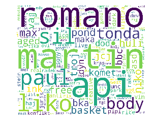

[figure not shown]

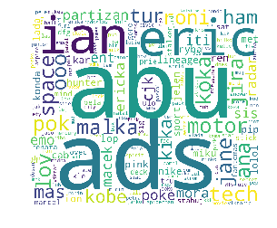

[figure not shown]

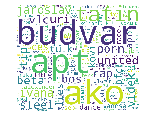

```python
%matplotlib inline
from wordcloud import WordCloud

import matplotlib.pyplot as plt
for t in range(ldaint.num_topics):
    top = []
    for i in range(0, 200):
        top.append(ldaint.show_topic(t, 200)[i][0])
        top
    plt.figure()
    wordcloud = WordCloud(
        background_color="white", width=1000, height=860,
        margin=1).generate(" ".join(top))
    plt.imshow(wordcloud)
    plt.axis("off")
    plt.show()
```

## LDA with english words

```python
import pickle
with open('../data/data2.pickle', 'rb') as f:
    data = pickle.load(f)
```

```python
import enchant
D = enchant.Dict('en_GB')
```

```python
data['putinlist2n1'] = ''
for index, row in data.iterrows():
    row['putinlist2n1'] = row['joinwithout2n1'].split()
```

```python
for index, row in data.iterrows():
    for ind, val in enumerate(row['putinlist2n1']):
        if D.check((row['putinlist2n1'])[ind]) == False:
            (row['putinlist2n1'])[ind] = ''
```

```python
for index, row in data.iterrows():
    for ind, val in enumerate(row['putinlist2n1']):
        if ((row['putinlist2n1'])[ind]).isdigit() == True:
            (row['putinlist2n1'])[ind] = ''
```

```python
data.rename(columns={'putinlist2n1':'engwords'}, inplace=True)
```

```python
with open('../data/datawitheng.pickle', 'wb') as f:
    pickle.dump(data, f)
```

```python
import pickle
with open('../data/languages.dms', 'rb') as f:
    eng_words_noint, french_words_noint, german_words_noint = pickle.load(f)
```

```python
texts_eng = eng_words_noint
my_stop_words = ['']
```

```python
from sklearn.feature_extraction.text import TfidfVectorizer

# change the max_df to get different results

tfidf_vectorizer = TfidfVectorizer(max_df=0.999, max_features=200000,
                                   min_df=0.001, stop_words=my_stop_words,
                                   use_idf=True, ngram_range=(1,3))

%time tfidf_matrix = tfidf_vectorizer.fit_transform(texts_eng)

print(tfidf_matrix.shape)
```

```
CPU times: user 412 ms, sys: 5.68 ms, total: 418 ms
Wall time: 417 ms
(10344, 170)
```

```python
terms_eng = tfidf_vectorizer.get_feature_names()
```

```python
import numpy as np
import gensim
import gensim.corpora as corpora
from gensim.utils import simple_preprocess
from gensim.models import CoherenceModel
```

```python
import pickle
with open('../data/datawitheng.pickle', 'rb') as f:
    data = pickle.load(f)
words = data['engwords']
```

```python
#( Create Dictionary )
y = []
for item in terms_eng:
    y.append(item)
z = np.array(y)
why = z.flatten()
z = list(z)

###I create a dictionary
id2wordENG = corpora.Dictionary(words)
print(id2wordENG)

#dic = corpora.Dictionary([why.split()])
# Create Corpus
#texts = data_lemmatized

### Term Document Frequency
corpusENG = [id2wordENG.doc2bow(terms_eng) for text in terms_eng]

#corpus = [id2word.doc2bow(tokenize(t)) for t in terms]
# View
#print(corpus[:1])
dictionaryENG = id2wordENG
```

```
Dictionary(3083 unique tokens: ['', 'chart', 'pan', 'pink', 'bulldog']...)
```

```python
corpusintENG = [id2wordENG.doc2bow(terms_eng) for text in terms_eng]
```

```python
from gensim import corpora, models
ldaENG = models.LdaModel(
    corpusintENG,
    num_topics=5,
    id2word=dictionaryENG,
    update_every=5,
    chunksize=10000,
    passes=1,
    random_state=8)
```

```python
ldaENG.show_topics()
print(ldaENG[corpusintENG[0]])
```

```
[(0, 0.42495555), (2, 0.08194645), (3, 0.022417603), (4, 0.46948037)]
```

```python
topicsENG = ldaENG.print_topics(5, num_words=20)
print(topicsENG)
```

```
[(0, '0.008*"neck" + 0.007*"fox" + 0.007*"tick" + 0.007*"genius" + 0.007*"dragon" + 0.007*"para" + 0.007*"cha" + 0.007*"pass" + 0.007*"via" + 0.007*"old" + 0.007*"fer" + 0.007*"predator" + 0.006*"risk" + 0.006*"killer" + 0.006*"metal" + 0.006*"sky" + 0.006*"big" + 0.006*"internet" + 0.006*"pop" + 0.…
```

```python
from wordcloud import WordCloud
```

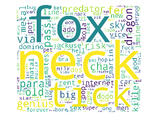

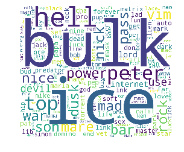

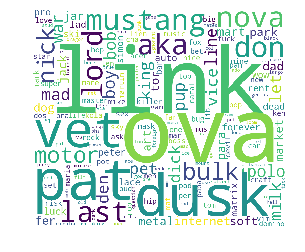

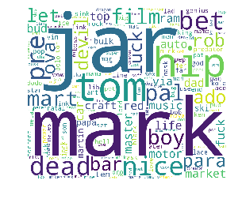

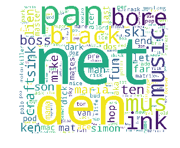

```python
%matplotlib inline

import matplotlib.pyplot as plt
for t in range(ldaENG.num_topics):
    topp = []
    for i in range(0, 200):
        topp.append(ldaENG.show_topic(t, 200)[i][0])
        topp
    plt.figure()
    wordcloudENG = WordCloud(
        background_color="white", width=1000, height=860,
        margin=1).generate(" ".join(topp))
    plt.imshow(wordcloudENG)
    plt.axis("off")
    plt.show()
```

# Password prediction

## Markov Chain

### Characters by characters

```python
import pickle

with open('../data/data_2.pickle', 'rb') as f:
    data = pickle.load(f)
```

Let the character 停 as a stop word to stop the password

```python
for index, val in data.iterrows():
    val['simplesplit'].append('停')
    val['original']+='停'
```

Try to get a transition matrix

```python
# take 10s
tranlist = []
count = []
for passwd in data['simplesplit']:
    for i in range(len(passwd)-1):
        temp = passwd[i] + passwd[i+1]
        if temp in tranlist:
            count[tranlist.index(temp)] = count[tranlist.index(temp)] + 1
        else:
            count.append(1)
            tranlist.append(temp)
```

```python
import re
alphabet = ''
for index, row in data.iterrows():
    alphabet = alphabet + row['original']
alphabet = list(set(alphabet))
```

Now we are going to calculate the transition matrix by observing the dataset.

Estimation $$Qij = \frac{num:\_from\_i\_to\_j}{num:\_from\_i}$$ If the num of events from i is zero, then the whole row is 0

```python
import numpy as np
matrix = np.zeros( (len(alphabet), len(alphabet)) )
mylist=[]
for i in range(len(alphabet)-1):
    for j in range(len(alphabet)-1):#range(len(alphabet)-1):
        # This time complexity needs to fix
        try:
            matrix[i,j] = count[tranlist.index(alphabet[i] + alphabet[j])]
        except:
            continue
```

Get the transition matrix

```python
matrix = (matrix.T / sum(matrix.T)).T
matrix[np.isnan(matrix)] = 0
```

```python
from bisect import bisect
from random import random
```

It is just a 1-step markov chain. so from i to j, we just need to find the largest probability.

```python
def findthemax(matrix, string, alphabet):
    position = alphabet.index(string[-1])
    for i in range(len(matrix[position])):
        if matrix[position, i] == (max(matrix[position])):
            print(alphabet[i])
            return (i)


def findthemin(matrix, string, alphabet):
    position = alphabet.index(string[-1])
    for i in range(len(matrix[position])):
        if matrix[position, i] == (min(matrix[position])):
            print(alphabet[i])
            return (i)


def generatemax(matrix, string, alphabet):
    print(string, end='')
    while (string[-1] != '停'):
        position = alphabet.index(string[-1])
        for i in range(len(matrix[position])):
            if matrix[position, i] == (max(matrix[position])):
                print(alphabet[i], end='')
                string = string + alphabet[i]


def generatebyQ(matrix, string, alphabet):
    from bisect import bisect
    from random import random
    print(string, end='')
    j = 0
    while (string[-1] != '停'):
        if j > 5:
            break
        position = alphabet.index(string[-1])
        # choose string by the transition matrix
        P = matrix[position]
        cdf = [P[0]]
        for i in range(1, len(P)):
            cdf.append(cdf[-1] + P[i])

        random_ind = bisect(cdf, random())
        if alphabet[random_ind] != '停':
            print(alphabet[random_ind], end='')
        string = string + alphabet[random_ind]
        j += 1
```

Show 6 passwords generated by markov model

```python
import string
import random


def id_generator(size=6, chars=string.ascii_lowercase + string.digits):
    return ''.join(random.choice(chars) for _ in range(size))
```

```python
random.seed(20)

for i in range(6):
    string = id_generator()
    a = generatebyQ(matrix, string, alphabet)
    print()
```

```
jqgukbigndet
nmuvv108
zfnpcm23
stqkhbankoru
triv2jenkath
hi1wohe00000
```

### Words by words

```python
import pickle

with open('../data/data_1.pickle', 'rb') as f:
    data = pickle.load(f)
```

```python
for index, val in data.iterrows():
    val['extrawordsplit'].append('停')
    val['original'] += '停'
```

```python
# take about 1 min
tranlist = []
count = []
for passwd in data['extrawordsplit']:
    for i in range(len(passwd) - 1):
        temp = [passwd[i], passwd[i + 1]]
        if temp in tranlist:
            count[tranlist.index(temp)] = count[tranlist.index(temp)] + 1
        else:
            count.append(1)
            tranlist.append(temp)
```

```python
alphabet = []
for i in tranlist:
    for j in i:
        alphabet.append(j)
alphabet = list(set(alphabet))
```

```python
# take about 30s
import numpy as np
matrix = np.zeros((len(alphabet), len(alphabet)))
mylist = []
for list1 in tranlist:
    i = alphabet.index(list1[0])
    j = alphabet.index(list1[1])
    matrix[i, j] = matrix[i, j] + 1
```

Get the transition matrix

```python
# take about 30s
matrix = (matrix.T / sum(matrix.T)).T
matrix[np.isnan(matrix)] = 0
```

Because this matrix is too large to save in a pickle, please just wait a while to run it.

```python
import random


def generatebyQQ(matrix, alphabet):
    from bisect import bisect
    from random import random

    string = alphabet[np.random.randint(len(alphabet))]
    print(string, end='')
    j = 0
    while (string != '停'):
        if j >= 3:
            break
        position = alphabet.index(string)
        # choose string by the transition matrix
        P = matrix[position]
        cdf = [P[0]]
        for i in range(1, len(P)):
            cdf.append(cdf[-1] + P[i])

        random_ind = bisect(cdf, random())
        if alphabet[random_ind] != '停':
            print(alphabet[random_ind], end='')
        string = alphabet[random_ind]
        j = j + 1
```

```python
for i in range(6):
    generatebyQQ(matrix, alphabet)
    print()
```

```
kokosynasnehu
thaifighter
extraux
6734adagon4232466
ycenpyravu6
stri
```

## Bigrams

Try to make model more complicated and more realistic.

### Characters by characters

```python
import pickle

with open('../data/data_2.pickle', 'rb') as f:
    data = pickle.load(f)
```

Recource: https://sookocheff.com/post/nlp/ngram-modeling-with-markov-chains/

```python
import random


class MarkovChain:

    def __init__(self):
        self.memory = {}

    def _learn_key(self, key, value):
        if key not in self.memory:
            self.memory[key] = []

        self.memory[key].append(value)

    def learn(self, text):
        tokens = text.split(" ")
        bigrams = [(tokens[i], tokens[i + 1]) for i in range(0, len(tokens) - 1)]
        for bigram in bigrams:
            self._learn_key(bigram[0], bigram[1])

    def _next(self, current_state):
        next_possible = self.memory.get(current_state)

        if not next_possible:
            next_possible = self.memory.keys()

        return random.sample(next_possible, 1)[0]

    def babble(self, amount, state=''):
        if not amount:
            return state

        next_word = self._next(state)
        return state + ' ' + self.babble(amount - 1, next_word)
```

```python
for index, val in data.iterrows():
    val['simplesplit'] = " ".join(val['simplesplit'])
```

```python
m = MarkovChain()

for index, val in data.iterrows():
    m.learn(val['simplesplit'])
```

```python
random.seed(8)
for i in range(6):
    print(m.babble(10).replace(" ", ""))
```

```
domo19870
1xdra34772
skyhob15
52036ya
hodikot681
22ZxxgOg
```

### Words by words in bigram model

```python
import pickle

with open('../data/data_1.pickle', 'rb') as f:
    data = pickle.load(f)
```

```python
data['newextrawordsplit'] = ''
for index, val in data.iterrows():
    val['newextrawordsplit'] = " ".join(val['extrawordsplit'])
```

```python
m = MarkovChain()

for index, val in data.iterrows():
    m.learn(val['newextrawordsplit'])
```

```python
random.seed(33)
for i in range(6):
    print(m.babble(5).replace(" ", ""))
```

```
buksatko12345hope
anothercentricky
1996palopalo132
17101835
popteamdjpecc
p1exotko
```

```python
# try the n-grams: http://www.decontextualize.com/teaching/rwet/n-grams-and-markov-chains/
```

# Password Security (Password Strength)

```python
import pickle

with open('../data/data_2.pickle', 'rb') as f:
    data = pickle.load(f)
```

Example of zxcvbn package

```python
from zxcvbn import zxcvbn
# Test
results = zxcvbn('1234567')
print(results)
```

```
{'password': '1234567', 'guesses': Decimal('10'), 'guesses_log10': 1.0, 'sequence': [{'pattern': 'dictionary', 'i': 0, 'j': 6, 'token': '1234567', 'matched_word': '1234567', 'rank': 9, 'dictionary_name': 'passwords', 'reversed': False, 'l33t': False, 'base_guesses': 9, 'uppercase_variations': 1, 'l3…
```

Take about 30s

```python
data['password_strength'] = ''
data['fixcap_with_pswd_strength'] = ''
for index, row in data.iterrows():
    # simple split for each row

    results = zxcvbn(row['original'])
    temp = results['score']
    if temp == 0:
        password_score = 'Weakest'
    elif temp == 1:
        password_score = 'Weak'
    elif temp == 2:
        password_score = 'Medium'
    elif temp == 3:
        password_score = 'Strong'
    else:
        password_score = 'Strongest'
    row['password_strength'] = password_score
# data['fixcap_with_pswd_strength'] =
```

## LDA guide 1 - add strength only

```python
docs_raw = list(data['fixcapital']+" "+data['password_strength'])
print(len(docs_raw))
```

```
38650
```

```python
tf_vectorizer = CountVectorizer(strip_accents = 'unicode',
                                stop_words = 'english',
                                lowercase = True,
                                # token choose the words with more than 4 length and get rid of the speical words
                                token_pattern = r'\b[a-zA-Z0-9]{3,}\b',
                                max_df = 0.5,
                                min_df = 10)
dtm_tf = tf_vectorizer.fit_transform(docs_raw)
print(dtm_tf.shape)
```

```
(38650, 668)
```

```python
tfidf_vectorizer = TfidfVectorizer(**tf_vectorizer.get_params())
dtm_tfidf = tfidf_vectorizer.fit_transform(docs_raw)
print(dtm_tfidf.shape)
```

```
(38650, 668)
```

```python
# for TF DTM
lda_tf = LatentDirichletAllocation(n_components=10, random_state=0)
%time lda_tf.fit(dtm_tf)
# for TFIDF DTM
lda_tfidf = LatentDirichletAllocation(n_components=10, random_state=0)
%time lda_tfidf.fit(dtm_tfidf)
```

```
CPU times: user 34.6 s, sys: 26.5 ms, total: 34.6 s
Wall time: 24 s
CPU times: user 31.9 s, sys: 36.8 ms, total: 31.9 s
Wall time: 21.3 s
```

```
LatentDirichletAllocation(batch_size=128, doc_topic_prior=None,
             evaluate_every=-1, learning_decay=0.7,
             learning_method='batch', learning_offset=10.0,
             max_doc_update_iter=100, max_iter=10, mean_change_tol=0.001,
             n_components=10, n_jobs=None, n_topics=None, perp_tol=0.1,
             random_state=0, topic_word_prior=None,
             total_samples=1000000.0, verbose=0)
```

```python
pyLDAvis.sklearn.prepare(lda_tf, dtm_tf, tf_vectorizer)
```

[interactive chart not shown]

Get the password strength

```python
from zxcvbn import zxcvbn

for i in range(10):
    string11 = m.babble(4).replace(" ", "")

    try:
        results = zxcvbn(string11)
        print(string11,results['score'])
    except:
        continue
```

```
budek4l 2
dopice1983 3
hilkaurl56 3
555torrent 1
tabulka11 3
smile29hfmnd 4
lampard 1
h4ever 1
```

## LDA guide 2 - strength plus feedback

Take about 20s

```python
data['feedback'] = ''
for index, row in data.iterrows():
    # simple split for each row

    results = zxcvbn(row['original'])
    row['feedback'] = " ".join(results['feedback']['suggestions'])
    #row['feedback'] = results['feedback']['warning']+" ".join(results['feedback']['suggestions'])
```

```python
docs_raw = list(data['fixcapital']+" "+data['password_strength']+" "+data['feedback'])
print(len(docs_raw))
```

```
38650
```

```python
tf_vectorizer = CountVectorizer(strip_accents = 'unicode',
                                stop_words = 'english',
                                lowercase = True,
                                # token choose the words with more than 4 length and get rid of the speical words
                                token_pattern = r'\b[a-zA-Z0-9]{3,}\b',
                                max_df = 0.5,
                                min_df = 10)
dtm_tf = tf_vectorizer.fit_transform(docs_raw)
print(dtm_tf.shape)
```

```
(38650, 694)
```

```python
tfidf_vectorizer = TfidfVectorizer(**tf_vectorizer.get_params())
dtm_tfidf = tfidf_vectorizer.fit_transform(docs_raw)
print(dtm_tfidf.shape)
```

```
(38650, 694)
```

```python
# for TF DTM
lda_tf = LatentDirichletAllocation(n_components=10, random_state=0)
%time lda_tf.fit(dtm_tf)
# for TFIDF DTM
lda_tfidf = LatentDirichletAllocation(n_components=10, random_state=0)
%time lda_tfidf.fit(dtm_tfidf)
```

```
CPU times: user 38.4 s, sys: 48.4 ms, total: 38.5 s
Wall time: 27.9 s
CPU times: user 32.6 s, sys: 27 ms, total: 32.6 s
Wall time: 22 s
```

```
LatentDirichletAllocation(batch_size=128, doc_topic_prior=None,
             evaluate_every=-1, learning_decay=0.7,
             learning_method='batch', learning_offset=10.0,
             max_doc_update_iter=100, max_iter=10, mean_change_tol=0.001,
             n_components=10, n_jobs=None, n_topics=None, perp_tol=0.1,
             random_state=0, topic_word_prior=None,
             total_samples=1000000.0, verbose=0)
```

```python
pyLDAvis.sklearn.prepare(lda_tf, dtm_tf, tf_vectorizer)
```

[interactive chart not shown]

## LDA guide 3 - deep exploration

Add all the password analysis information

```python
def pswd_analyse(results):
    mylist = []
    for i in range(len(results['sequence'])):
        for key, val in results['sequence'][i].items():
            if key == 'pattern':
                if val == 'dictionary':
                    #if results['sequence'][i]['dictionary_name'] != 'passwords':
                    mylist.append(results['sequence'][i]['dictionary_name'])
                elif val == 'sequence':
                    mylist.append(results['sequence'][i]['sequence_name'])
                elif val == 'regex':
                    mylist.append(results['sequence'][i]['regex_name'])
                elif val == 'date':
                    mylist.append(val)
                elif val == 'bruteforce':
                    mylist.append(val)
                elif val == 'repeat':
                    mylist.append(val)
                elif val == 'spatial':
                    mylist.append(val)
                else:
                    mylist.append(val)
                    print(val)
                    print(results)
    return(mylist)
```

```python
# test
results = zxcvbn('HelloWorld')
print(results)
mylist = pswd_analyse(results)
mylist
```

```
{'password': 'HelloWorld', 'guesses': Decimal('45192'), 'guesses_log10': 4.655061561728271, 'sequence': [{'pattern': 'dictionary', 'i': 0, 'j': 4, 'token': 'Hello', 'matched_word': 'hello', 'rank': 83, 'dictionary_name': 'passwords', 'reversed': False, 'l33t': False, 'base_guesses': 83, 'uppercase_v…
```

```
['passwords', 'english_wikipedia']
```

```python
import re

data['withoutspecialwords'] = ''
for index, row in data.iterrows():
    # simple split for each row
    row['withoutspecialwords'] = "".join(re.findall(r'[0-9]+|[a-zA-Z]+',row['original']))
```

Take about 20s

```python
data['pswd_analysis'] = ''
for index, row in data.iterrows():
    if row['withoutspecialwords']:
        results = zxcvbn(row['withoutspecialwords'])
        mylist = pswd_analyse(results)

    row['pswd_analysis'] = " ".join(mylist)
# data['fixcap_with_pswd_strength'] =
```

```python
data['feedback'][43]
```

```
"Add another word or two. Uncommon words are better. Capitalization doesn't help very much."
```

```python
docs_raw = list(data['fixcapital']+" "+data['password_strength']+" "+data['feedback']+" "+data['pswd_analysis'])
print(len(docs_raw))
```

```
38650
```

```python
def LDA_pwstrenth(docs_raw,n_topics):
    tf_vectorizer = CountVectorizer(strip_accents = 'unicode',
                                    stop_words = ['english','aren','doesn','this','very','don','like','much','than','help','thems'],
                                    lowercase = True,
                                    # token choose the words with more than 4 length and get rid of the speical words
                                    token_pattern = r'\b[a-zA-Z0-9]{3,}\b',
                                    max_df = 0.5,
                                    min_df = 10)
    dtm_tf = tf_vectorizer.fit_transform(docs_raw)
    tfidf_vectorizer = TfidfVectorizer(**tf_vectorizer.get_params())
    dtm_tfidf = tfidf_vectorizer.fit_transform(docs_raw)
    # for TF DTM
    lda_tf = LatentDirichletAllocation(n_components=n_topics, random_state=0)
    %time lda_tf.fit(dtm_tf)
    # for TFIDF DTM
    lda_tfidf = LatentDirichletAllocation(n_components=n_topics, random_state=0)
    %time lda_tfidf.fit(dtm_tfidf)
    return(lda_tf, dtm_tf, tf_vectorizer)
```

```python
# Take about 2 min
# lda_tf_passwd strenth plus version
lda_tf_pwplus, dtm_tf_pwplus, tf_vectorizer_pwplus = LDA_words_numbers(docs_raw,10)
pyLDAvis.sklearn.prepare(lda_tf_pwplus, dtm_tf_pwplus, tf_vectorizer_pwplus)
```

```
CPU times: user 40 s, sys: 31.9 ms, total: 40 s
Wall time: 29.4 s
CPU times: user 35.5 s, sys: 34.3 ms, total: 35.5 s
Wall time: 24.9 s
```

[interactive chart not shown]